# gsw

Dan Kelley and Clark Richards

2017-08-09

**Abstract.** The `gsw` package provides an R implementation of the Gibbs SeaWater toolbox for the calculation of seawater properties (version 3.05). This vignette outlines how to use `gsw` alone or as part of the `oce` package.

# 1 Introduction

In recent years, thermodynamic considerations have led to improved formulae for the calculation of seawater properties (IOC, 2010; Millero et al 2010), an important component of which is the Gibbs-SeaWater (GSW) toolbox (McDougall 2011; Pawlowicz et al 2012). The `gsw` package is an R version of GSW, which may be used independently or within the more general `oce` package (Kelley and Richards 2016).

This vignette sketches how to use `gsw`. Readers are assumed to be familiar with oceanographic processing, and at least somewhat familiar with GSW. A good resource for learning more about GSW is http://www.teos-10.org, which provides technical manuals for the Matlab version of GSW http://www.teos-10.org/pubs/gsw/html/gsw_contents.html, along with white papers and links to the growing peer-reviewed literature on the topic.

The `gsw` framework involves a series of wrappers that connect R with the C version of the Gibbs Seawater library. This yields high processing speed and the minimization of transliteration errors increases reliability. The incorporation of GSW check values into the package-building process is an additional measure taken to achieve reliability.

By design, the documentation of `gsw` functions is spare, amounting mainly to an explanation of function arguments and return values, with most other details being provided through hyperlinks to the GSW reference documentation. The idea is to avoid duplication and to encourage users to consult the technical materials linked to the GSW functions mimicked in `gsw`. The GSW system is somewhat complex, and analysts owe it to themselves to learn how it works, and also to develop an appreciation for its scientific context by consulting various documents at http://www.teos-10.org, including expansive white papers and pointers to the growing peer-reviewed literature (Wright et al. 2011; McDougall et al. 2012; Graham et al. 2013)

# 2 Using gsw independent of oce

Suppose a water sample taken at pressure (For practical reasons, `gsw` goes beyond SI to incorporate oceanographic units, such as decibars for pressure.) 100 dbar, longitude 188E and latitude 4N, reveals Practical Salinity 35 and in-situ temperature 10$^\circ$C (ITS-90). Then the Absolute Salinity may be calculated as follows.

```r
library(gsw)
SA <- gsw_SA_from_SP(SP=35, p=100, longitude=188, latitude=4)
```

This yields `SA`=35.1655491 [g/kg], which can then be used to calculate Conservative Temperature as follows.

```r
CT <- gsw_CT_from_t(SA=SA, t=10, p=100)
```

The above yields `CT`=9.9782488 [$^\circ$C]. Readers familiar with GSW will recognize the function and argument names, and are likely to find the other functions needed for their work among the roughly sixty functions that `gsw` provides.

# 3 Using gsw within oce

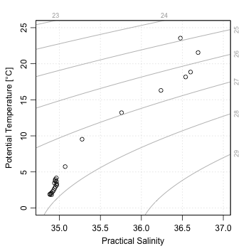

**Figure 1.** TS diagram with UNESCO formulation

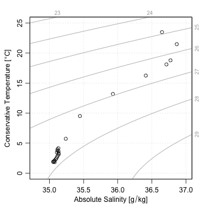

**Figure 2.** TS diagram with GSW formulation

Many `oce` plotting functions have an argument named `eos` that can be set to the string `"unesco"` to get the older seawater formulation, or to `"gsw"` to get the newer one. For example, the `section` dataset provided by `oce` holds a sequence of CTD casts in the North Atlantic. Individual casts may be selected by index, so a TS diagram of the station at index 100 (south of Cape Cod in 4000 m of water) can be plotted as follows (Figure 1).

```r
library(oce)
data(section)
ctd <- section[["station", 100]]
Slim <- c(34.8, 37.0)
Tlim <- c(0, 25)
plotTS(ctd, Slim=Slim, Tlim=Tlim, eos="unesco")
```

For comparison, it helps to plot a `gsw` equivalent with the same plot limits (Figure 2).

```r
plotTS(ctd, Slim=Slim, Tlim=Tlim, eos="gsw")
```

```r
f <- (section[["CT"]] - section[["theta"]]) / section[["CT"]]
hist(f, main="", xlab="(CT-theta)/CT")
```

A salinity comparison (Figure 4) is constructed with

[figure not shown]

**Figure 3.** Comparison of GSW Conservative Temperature and UNESCO potential temperature for the `section` dataset, spanning the mid-latitude North Atlantic.

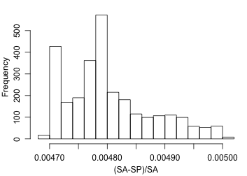

**Figure 4.** Comparison of Absolute Salinity and Practical salinity for the `section` dataset.

```r
f <- (section[["SA"]] - section[["salinity"]]) / section[["SA"]]
hist(f, main="", xlab="(SA-SP)/SA")
```

An examination of worldwide spatial patterns is also informative. Figure 5, for example, is produced as follows.

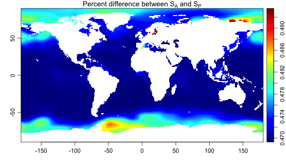

**Figure 5.** Percent difference between surface Absolute Salinity and Practical Salinity, for Levitus dataset.

```r
library(oce)
data("levitus", package="ocedata")
SSS <- levitus$SSS
dim <- dim(SSS)
ll <- expand.grid(lon=levitus$longitude, lat=levitus$latitude)
SA <- gsw_SA_from_SP(levitus$SSS, 0, ll$lon, ll$lat)
per <- 100 * (1 - levitus$SSS / SA)
imagep(levitus$longitude, levitus$latitude, per, col=oceColorsJet,
       zlim=quantile(per, c(0.001, 0.999), na.rm=TRUE))
title(expression("Percent difference between " * S[A] * " and " * S[P]))
```

Note the use of quantile-specified scales for the images, the colour mappings of which would otherwise be controlled by isolated low-saline waters, yielding little to see in the wider expanses of the world ocean; a broader context has been detailed in the literature (McDougall et al. 2012).

# 4 References

Graham, F. S. and T. J. McDougall, 2012. Quantifying the Nonconservative Production of Conservative Temperature, Potential Temperature, and Entropy. Journal of Physical Oceanography, 43(5):838-862. http://dx.doi.org/10.1175/JPO-D-11-0188.1

IOC and SCOR and IAPSO, 2010. Intergovernmental Oceanographic Commission, Manuals and Guide, 56, UNESCO. http://www.teos-10.org/pubs/TEOS-10_Manual.pdf

Kelley, D. and C. Richards, 2016. oce: Analysis of Oceanographic data, R package version 0.9-18. Comprehensive R Archive Network. http://dankelley.github.com/oce

McDougall, T. J. and P. M. Barker,2011. Getting started with TEOS-10 and the Gibbs Seawater (GSW) Oceanographic Toolbox. SCOR/IAPSO WG127. 978-0-646-55621-5.

McDougall, T. J., D. R. Jackett, F. J. Millero, R. Pawlowicz and P. M. Barker, 2012. A global algorithm for estimating Absolute Salinity. Ocean Science, 8:1123-1134. http://www.ocean-sci.net/8/1123/2012/os-8-1123-2012.pdf

Millero, F. J. 2010. History of the equation of state of seawater. Oceanography, 23:18-33. http://www.tos.org/oceanography/article/history-of-the-equation-of-state-of-seawater

Pawlowicz, R., T. McDougall, R. Feistel and R. Tailleux, 2012. Preface ``An historical perspective on the development of the Thermodynamic Equation of Seawater–2010’’}. Ocean Science, 8:161-174. http://www.ocean-sci.net/8/161/2012/os-8-161-2012.pdf

Wright, D. G., R. Pawlowicz, T. J. McDougall, R. Feistel and G. M. Marion, 2011. Absolute Salinity, Density Salinity and the Reference-Composition Salinity Scale: present and future use in the seawater standard TEOS-10. Ocean Science, 7:1-26. http://www.ocean-sci.net/7/1/2011/os-7-1-2011.pdf